# Whiskey Notes

```r
library(MASS)
library(tidyverse)
```

```r
library(car)
```

```r
library(openintro)
```

```r
library(broom)
library(caret)
```

```r
library(kernlab)
```

```r
library(rpart)
library(rpart.plot)
library(plyr)
```

```r
library(boot)
```

```r
library(ISLR)
library(dplyr)
Meta_Critic_Whisky_Data <- read.csv("Meta_Critic_Whisky_Data.csv")
Meta_Critic_Whisky_Data
```

| Whisky | Age | MetaCritic | StDev | Num_of_Critics | Cost | Class | SuperCluster | Cluster | Country | Type |
| --- | --- | --- | --- | --- | --- | --- | --- | --- | --- | --- |
| Ledaig 42yo Dusgadh | 42 | 9.46 | 0.24 | 3 | >$300 CAD | SingleMalt-like | ABC | C | Scotland | Malt |
| Laphroaig 27yo 57.4% 1980-2007 (OB, 5 Oloroso Casks, 972 Bts) | 27 | 9.39 | 0.20 | 4 | >$300 CAD | SingleMalt-like | ABC | C | Scotland | Malt |
| Glenfarclas 40yo | 40 | 9.27 | 0.26 | 15 | >$300 CAD | SingleMalt-like | ABC | A | Scotland | Malt |
| Glengoyne 25yo | 25 | 9.20 | 0.23 | 14 | >$300 CAD | SingleMalt-like | ABC | A | Scotland | Malt |
| Amrut Spectrum (Batch 1) | 0 | 9.18 | 0.24 | 10 | $125-300 CAD | SingleMalt-like | ABC | C | India | Malt |
| Highland Park 25yo | 25 | 9.17 | 0.17 | 14 | >$300 CAD | SingleMalt-like | ABC | C | Scotland | Malt |
| Highland Park 40yo | 40 | 9.16 | 0.44 | 10 | >$300 CAD | SingleMalt-like | ABC | C | Scotland | Malt |
| Amrut Greedy Angels (8yo and 10yo) | 8 | 9.12 | 0.17 | 8 | >$300 CAD | SingleMalt-like | ABC | C | India | Malt |
| Balvenie TUN 1401 (all 9 batches) | 0 | 9.12 | 0.28 | 17 | >$300 CAD | SingleMalt-like | ABC | A | Scotland | Malt |
| Highland Park 30yo | 30 | 9.12 | 0.41 | 13 | >$300 CAD | SingleMalt-like | ABC | C | Scotland | Malt |

[output cut: 990 more lines]

# Data cleaning Exlplanations

Data used was accessed on March 17th. Data set is live Removed “Teaninich 10yo (F&F)” before importing because it was missing the Cost variable. Changed “Meta Critic” to “MetaCritic”, “#” to “Num_of_Critics”, “Super Cluster” to “SuperCluster”, “STDEV” to “StDev” to fix coding errors. Added age variable by taking the number of years aged from the Whisky category, signified by #yo in the title of the whisky. In the case of any whiskies with more than one year given, the minimum was taken. (Only example in my dataset “Amrut Greedy Angels (8yo and 10yo)” Other new entries with the same syntax should be treated the same).

# Exploritiory Graphs

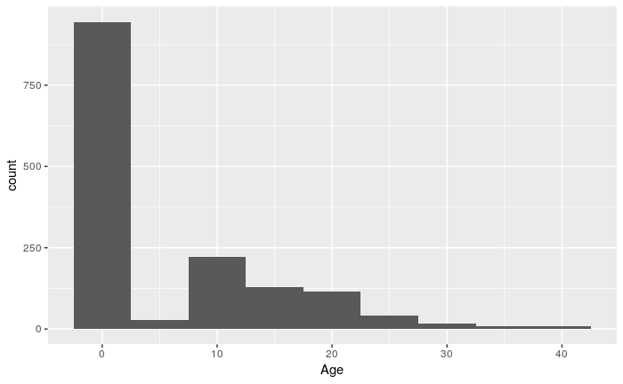

```r
ggplot(data=Meta_Critic_Whisky_Data, aes(x=Age)) + geom_histogram(binwidth = 5)
```

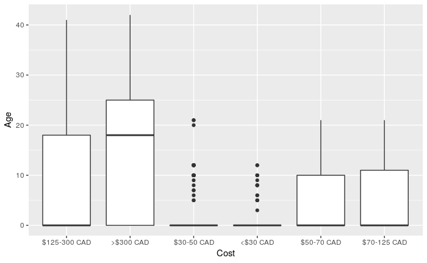

```r
ggplot(data=Meta_Critic_Whisky_Data, aes(x=Cost, y=Age))+ geom_boxplot()
```

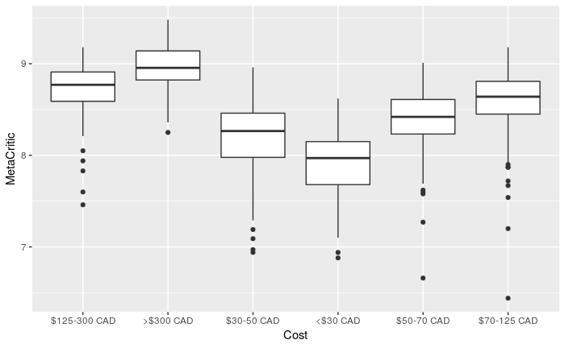

```r
ggplot(data=Meta_Critic_Whisky_Data, aes(x=Cost, y=MetaCritic))+ geom_boxplot()
```

# Cleaning Some Data

```r
Whisky_Data <- subset(Meta_Critic_Whisky_Data, select = -c(Cluster, SuperCluster))
#Since there is a large portion of data that does not list Cluster or SuperCluster, I have excluded it from my considerations. I chose not to put in a dummy variable as the clusters rely on taste and I cannot assume flavor profiles.
Whisky_Data<- na.omit(Whisky_Data)
Whisky_Data <- Whisky_Data[-c(1138),]
#No NAs, however, "Highland Queen" is missing both Country and Type, so I manually removed it
#Single instance of Irish instead of Ireland in Country variable
Whisky_Data
```

|  | Whisky | Age | MetaCritic | StDev | Num_of_Critics | Cost | Class | Country | Type |
| --- | --- | --- | --- | --- | --- | --- | --- | --- | --- |
| 1 | Ledaig 42yo Dusgadh | 42 | 9.46 | 0.24 | 3 | >$300 CAD | SingleMalt-like | Scotland | Malt |
| 2 | Laphroaig 27yo 57.4% 1980-2007 (OB, 5 Oloroso Casks, 972 Bts) | 27 | 9.39 | 0.20 | 4 | >$300 CAD | SingleMalt-like | Scotland | Malt |
| 3 | Glenfarclas 40yo | 40 | 9.27 | 0.26 | 15 | >$300 CAD | SingleMalt-like | Scotland | Malt |
| 4 | Glengoyne 25yo | 25 | 9.20 | 0.23 | 14 | >$300 CAD | SingleMalt-like | Scotland | Malt |
| 5 | Amrut Spectrum (Batch 1) | 0 | 9.18 | 0.24 | 10 | $125-300 CAD | SingleMalt-like | India | Malt |
| 6 | Highland Park 25yo | 25 | 9.17 | 0.17 | 14 | >$300 CAD | SingleMalt-like | Scotland | Malt |
| 7 | Highland Park 40yo | 40 | 9.16 | 0.44 | 10 | >$300 CAD | SingleMalt-like | Scotland | Malt |
| 8 | Amrut Greedy Angels (8yo and 10yo) | 8 | 9.12 | 0.17 | 8 | >$300 CAD | SingleMalt-like | India | Malt |
| 9 | Balvenie TUN 1401 (all 9 batches) | 0 | 9.12 | 0.28 | 17 | >$300 CAD | SingleMalt-like | Scotland | Malt |
| 10 | Highland Park 30yo | 30 | 9.12 | 0.41 | 13 | >$300 CAD | SingleMalt-like | Scotland | Malt |

[output cut: 990 more lines]

```r
Whisky_Data[292, "Country"] <- "Ireland"
```

```r
str(Whisky_Data)
```

```
'data.frame':   1516 obs. of  9 variables:
 $ Whisky        : Factor w/ 1517 levels "2 Gingers Irish Whiskey",..: 974 953 578 627 70 756 758 49 162 757 ...
 $ Age           : int  42 27 40 25 0 25 40 8 0 30 ...
 $ MetaCritic    : num  9.46 9.39 9.27 9.2 9.18 9.17 9.16 9.12 9.12 9.12 ...
 $ StDev         : num  0.24 0.2 0.26 0.23 0.24 0.17 0.44 0.17 0.28 0.41 ...
 $ Num_of_Critics: int  3 4 15 14 10 14 10 8 17 13 ...
 $ Cost          : Factor w/ 6 levels "$125-300 CAD",..: 2 2 2 2 1 2 2 2 2 2 ...
 $ Class         : Factor w/ 4 levels "Bourbon-like",..: 4 4 4 4 4 4 4 4 4 4 ...
 $ Country       : Factor w/ 19 levels "","Belgium","Canada",..: 12 12 12 12 7 12 12 7 12 12 ...
 $ Type          : Factor w/ 10 levels "","Barley","Blend",..: 7 7 7 7 7 7 7 7 7 7 ...
```

# Preliminary data splitting for test/train and stuff

```r
set.seed(3)
train_control_none <- trainControl(method="none")
train_control_cv <- trainControl(method="CV")
grid <- data.frame(cp = seq(from = 0, to = 0.25, by = 0.01))
train_rows <- createDataPartition(Whisky_Data$MetaCritic, p=0.7, list=FALSE)
Whisky_train <-Whisky_Data[train_rows, ]
Whisky_test <- Whisky_Data[-train_rows, ]
```

# Tree for predicting MetaCritic

```r
set.seed(3)
metaCritic_tree <- train(MetaCritic ~ . -Whisky, data=Whisky_Data,
                         tuneGrid = grid,
                         method="rpart")
```

```
There were missing values in resampled performance measures.
```

```r
metaCritic_tree
```

```
CART

1516 samples
   8 predictors

No pre-processing
Resampling: Bootstrapped (25 reps)
Summary of sample sizes: 1516, 1516, 1516, 1516, 1516, 1516, ...
Resampling results across tuning parameters:

  cp    RMSE       Rsquared   MAE
  0.00  0.2807235  0.5156523  0.2178860
  0.01  0.2751636  0.5156731  0.2121810
  0.02  0.2897306  0.4630501  0.2223603
  0.03  0.3068062  0.3978864  0.2360855
  0.04  0.3123584  0.3759922  0.2402832
  0.05  0.3208960  0.3419685  0.2481223
  0.06  0.3277496  0.3135907  0.2547553
  0.07  0.3394850  0.2630374  0.2652535
  0.08  0.3422153  0.2508546  0.2677941
  0.09  0.3498928  0.2156476  0.2736218
  0.10  0.3552645  0.1915534  0.2783279
  0.11  0.3579781  0.1795544  0.2807287
  0.12  0.3587160  0.1762735  0.2813820
  0.13  0.3587160  0.1762735  0.2813820
  0.14  0.3587160  0.1762735  0.2813820
  0.15  0.3587160  0.1762735  0.2813820
  0.16  0.3587160  0.1762735  0.2813820
  0.17  0.3587160  0.1762735  0.2813820
  0.18  0.3587160  0.1762735  0.2813820
  0.19  0.3656384  0.1701509  0.2862469
  0.20  0.3704378  0.1658516  0.2894612
  0.21  0.3799753  0.1535196  0.2958392
  0.22  0.3874658  0.1480159  0.2999984
  0.23  0.3922450  0.1378918  0.3024934
  0.24  0.3930795  0.1483469  0.3027292
  0.25  0.3930795  0.1483469  0.3027292

RMSE was used to select the optimal model using the smallest value.
The final value used for the model was cp = 0.01.
```

```r
meta_tree_model <- metaCritic_tree$finalModel
meta_tree_model
```

```
n= 1516

node), split, n, deviance, yval
      * denotes terminal node

  1) root 1516 235.072700 8.547144
    2) StDev>=0.485 288  63.088730 8.188472
      4) Cost<$30 CAD>=0.5 46   4.818141 7.684565 *
      5) Cost<$30 CAD< 0.5 242  44.369920 8.284256
       10) Cost$30-50 CAD>=0.5 44   6.623643 7.916136 *
       11) Cost$30-50 CAD< 0.5 198  30.458730 8.366061
         22) StDev>=0.99 8   3.780750 7.547500 *
         23) StDev< 0.99 190  21.091950 8.400526
           46) Cost>$300 CAD< 0.5 170  16.492240 8.354706 *
           47) Cost>$300 CAD>=0.5 20   1.209000 8.790000 *
    3) StDev< 0.485 1228 126.244900 8.631262
      6) Cost>$300 CAD< 0.5 1082  97.464880 8.583651
       12) StDev>=0.285 634  54.345810 8.489211
         24) Cost$30-50 CAD>=0.5 105   7.282625 8.276952 *
         25) Cost$30-50 CAD< 0.5 529  41.393550 8.531342
           50) Cost<$30 CAD>=0.5 34   2.315826 8.141471 *
           51) Cost<$30 CAD< 0.5 495  33.554750 8.558121
            102) Cost$50-70 CAD>=0.5 162   9.306161 8.409074 *
            103) Cost$50-70 CAD< 0.5 333  18.898970 8.630631 *
       13) StDev< 0.285 448  29.462430 8.717299
         26) Cost$50-70 CAD>=0.5 78   4.334668 8.529359 *
         27) Cost$50-70 CAD< 0.5 370  21.791890 8.756919
           54) Cost$30-50 CAD>=0.5 31   2.254019 8.448387 *
           55) Cost$30-50 CAD< 0.5 339  16.317070 8.785133 *
      7) Cost>$300 CAD>=0.5 146   8.150134 8.984110 *
```

```
Bad 'data' field in model 'call'.
To silence this warning:
    Call prp with roundint=FALSE,
    or rebuild the rpart model with model=TRUE.
```

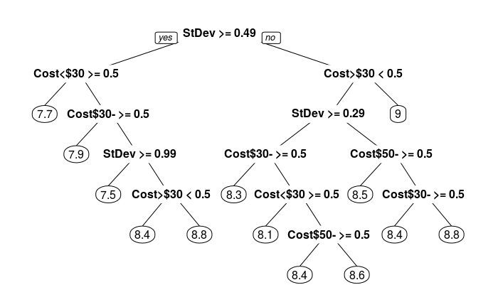

```r
prp(meta_tree_model)
```

```
Bad 'data' field in model 'call'.
To silence this warning:
    Call rpart.plot with roundint=FALSE,
    or rebuild the rpart model with model=TRUE.
```

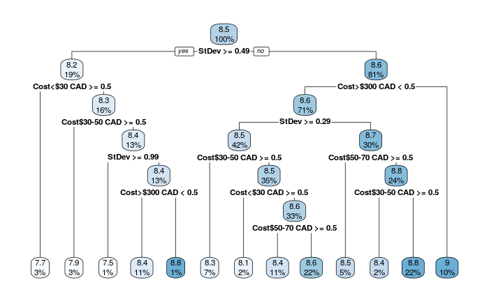

```r
rpart.plot(meta_tree_model)
```

# Tree to predict Cost

```r
set.seed(3)
cost_tree <- train(Cost ~ . -Whisky, data=Whisky_Data, tuneGrid = grid, method="rpart")
cost_tree
```

```
CART

1516 samples
   8 predictors
   6 classes: '$125-300 CAD', '>$300 CAD', '$30-50 CAD', '<$30 CAD', '$50-70 CAD', '$70-125 CAD'

No pre-processing
Resampling: Bootstrapped (25 reps)
Summary of sample sizes: 1516, 1516, 1516, 1516, 1516, 1516, ...
Resampling results across tuning parameters:

  cp    Accuracy   Kappa
  0.00  0.4298731  0.276154219
  0.01  0.4555859  0.287521871
  0.02  0.4341229  0.254876197
  0.03  0.4194329  0.233999840
  0.04  0.3957514  0.182249125
  0.05  0.3674156  0.114683442
  0.06  0.3342382  0.033411583
  0.07  0.3277610  0.015232899
  0.08  0.3234917  0.006761045
  0.09  0.3200709  0.000000000
  0.10  0.3200709  0.000000000
  0.11  0.3200709  0.000000000
  0.12  0.3200709  0.000000000
  0.13  0.3200709  0.000000000
  0.14  0.3200709  0.000000000
  0.15  0.3200709  0.000000000
  0.16  0.3200709  0.000000000
  0.17  0.3200709  0.000000000
  0.18  0.3200709  0.000000000
  0.19  0.3200709  0.000000000
  0.20  0.3200709  0.000000000
  0.21  0.3200709  0.000000000
  0.22  0.3200709  0.000000000
  0.23  0.3200709  0.000000000
  0.24  0.3200709  0.000000000
  0.25  0.3200709  0.000000000

Accuracy was used to select the optimal model using the largest value.
The final value used for the model was cp = 0.01.
```

```r
cost_tree_model <- cost_tree$finalModel
cost_tree_model
```

```
n= 1516

node), split, n, loss, yval, (yprob)
      * denotes terminal node

 1) root 1516 1030 $70-125 CAD (0.2 0.11 0.12 0.057 0.19 0.32)
   2) MetaCritic>=8.455 971  610 $70-125 CAD (0.28 0.17 0.047 0.0051 0.13 0.37)
     4) Age>=22.5 74   13 >$300 CAD (0.18 0.82 0 0 0 0) *
     5) Age< 22.5 897  536 $70-125 CAD (0.29 0.11 0.051 0.0056 0.14 0.4)
      10) Age>=16.5 130   54 $125-300 CAD (0.58 0.19 0.023 0 0.046 0.15) *
      11) Age< 16.5 767  426 $70-125 CAD (0.24 0.098 0.056 0.0065 0.16 0.44) *
   3) MetaCritic< 8.455 545  381 $50-70 CAD (0.066 0.0092 0.25 0.15 0.3 0.23)
     6) TypeMalt< 0.5 230  146 $30-50 CAD (0.022 0.0043 0.37 0.34 0.17 0.1)
      12) MetaCritic< 8.11 106   47 <$30 CAD (0.0094 0 0.32 0.56 0.066 0.047)
        24) StDev< 0.455 32   13 $30-50 CAD (0 0 0.59 0.25 0.094 0.063) *
        25) StDev>=0.455 74   23 <$30 CAD (0.014 0 0.2 0.69 0.054 0.041) *
      13) MetaCritic>=8.11 124   74 $30-50 CAD (0.032 0.0081 0.4 0.16 0.25 0.15) *
     7) TypeMalt>=0.5 315  189 $50-70 CAD (0.098 0.013 0.16 0.0063 0.4 0.32)
      14) StDev>=0.465 110   64 $70-125 CAD (0.15 0.0091 0.18 0 0.24 0.42) *
      15) StDev< 0.465 205  105 $50-70 CAD (0.068 0.015 0.15 0.0098 0.49 0.27) *
```

```
Bad 'data' field in model 'call'.
To silence this warning:
    Call prp with roundint=FALSE,
    or rebuild the rpart model with model=TRUE.
```

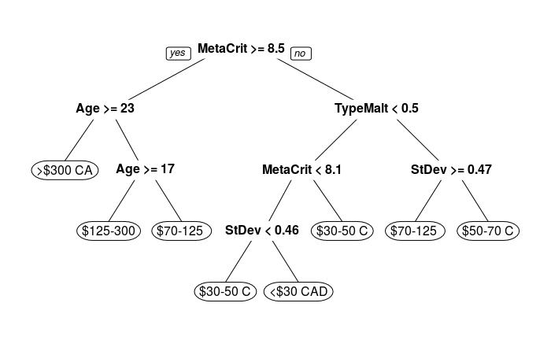

```r
prp(cost_tree_model)
```

```
Bad 'data' field in model 'call'.
To silence this warning:
    Call rpart.plot with roundint=FALSE,
    or rebuild the rpart model with model=TRUE.
```

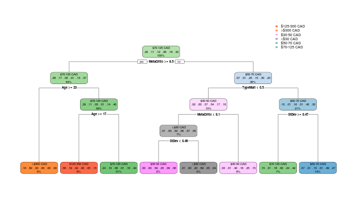

```r
rpart.plot(cost_tree_model)
```

# MTRY ??

```r
set.seed(3)
meta_forest <- train(MetaCritic ~ . -Whisky, data=Whisky_train, method = "rf", trControl= train_control_cv, tuneGrid = data.frame(mtry = 6), importance = TRUE)
pred_meta_forest <- predict(meta_forest, newdata= Whisky_test)
postResample(pred_meta_forest, Whisky_test$MetaCritic)
```

```
     RMSE  Rsquared       MAE
0.2339868 0.6527606 0.1823442
```

# ??? I know we can sort into categories, it’s a tree. What should I do instead to analize this?

```r
set.seed(3)
cost_forest <- train(Cost ~ . -Whisky, data=Whisky_train,
                     method = "rf",
                     trControl= train_control_cv,
                     tuneGrid = data.frame(mtry = 6),
                     importance = TRUE)
pred_cost_forest <- predict(cost_forest, newdata= Whisky_test)
postResample(pred_cost_forest, Whisky_test$MetaCritic)
```

```
‘-’ not meaningful for factors‘-’ not meaningful for factors
```

```
    RMSE Rsquared      MAE
      NA       NA       NA
```

# Tree to predict MetaCritic only Categorical <- Do I give a shit about this? Did it for funsies, but what does it actually tell me, if anything?

```r
set.seed(3)
meta_cat_tree <- train(MetaCritic ~ . -Whisky -StDev -Num_of_Critics, data=Whisky_train, tuneGrid = grid, method="rpart")
```

```
There were missing values in resampled performance measures.
```

```r
meta_cat_tree
```

```
CART

1063 samples
   8 predictors

No pre-processing
Resampling: Bootstrapped (25 reps)
Summary of sample sizes: 1063, 1063, 1063, 1063, 1063, 1063, ...
Resampling results across tuning parameters:

  cp    RMSE       Rsquared   MAE
  0.00  0.3031698  0.4260828  0.2300056
  0.01  0.3081040  0.3986917  0.2339352
  0.02  0.3089803  0.3947088  0.2352903
  0.03  0.3089679  0.3939112  0.2354268
  0.04  0.3089963  0.3938887  0.2354702
  0.05  0.3164611  0.3643299  0.2412321
  0.06  0.3203684  0.3490514  0.2444155
  0.07  0.3241109  0.3336174  0.2474512
  0.08  0.3315863  0.3021817  0.2530065
  0.09  0.3422210  0.2562993  0.2615163
  0.10  0.3471998  0.2334801  0.2652060
  0.11  0.3557822  0.1937479  0.2720468
  0.12  0.3634978  0.1589684  0.2785320
  0.13  0.3686676  0.1401851  0.2824421
  0.14  0.3755599  0.1262544  0.2879387
  0.15  0.3789509  0.1230914  0.2903376
  0.16  0.3829680  0.1229546  0.2934766
  0.17  0.3877252  0.1255531  0.2971730
  0.18  0.3911238  0.1136551  0.2996320
  0.19  0.3934400  0.1165912  0.3013734
  0.20  0.3934400  0.1165912  0.3013734
  0.21  0.3951673        NaN  0.3026272
  0.22  0.3951673        NaN  0.3026272
  0.23  0.3951673        NaN  0.3026272
  0.24  0.3951673        NaN  0.3026272
  0.25  0.3951673        NaN  0.3026272

RMSE was used to select the optimal model using the smallest value.
The final value used for the model was cp = 0.
```

```r
meta_cat_model <- meta_cat_tree$finalModel
meta_cat_model
```

```
n= 1063

node), split, n, deviance, yval
      * denotes terminal node

    1) root 1063 166.31140000 8.549944
      2) Cost<$30 CAD>=0.5 58   7.40438800 7.913966
        4) ClassScotch-like>=0.5 15   1.56077300 7.678667 *
        5) ClassScotch-like< 0.5 43   4.72342800 7.996047
         10) Age< 5.5 36   3.98585600 7.946111
           20) TypeBlend< 0.5 15   1.02489300 7.907333 *
           21) TypeBlend>=0.5 21   2.92229500 7.973810 *
         11) Age>=5.5 7   0.18614290 8.252857 *
      3) Cost<$30 CAD< 0.5 1005 134.09400000 8.586647
        6) Cost$30-50 CAD>=0.5 128  17.17173000 8.227891
         12) CountryScotland>=0.5 51   7.65883500 8.105882
           24) Age< 2.5 31   6.10377400 8.065161
             48) ClassSingleMalt-like>=0.5 20   5.18922000 8.053000 *
             49) ClassSingleMalt-like< 0.5 11   0.90621820 8.087273 *
           25) Age>=2.5 20   1.42398000 8.169000
             50) ClassSingleMalt-like>=0.5 12   0.82129170 8.154167 *
             51) ClassSingleMalt-like< 0.5 8   0.59608750 8.191250 *
         13) CountryScotland< 0.5 77   8.25087000 8.308701
           26) TypeRye< 0.5 68   6.93548700 8.274559
             52) Age< 3 55   5.84155300 8.218364
              104) CountryCanada>=0.5 16   2.54437500 8.111250 *
              105) CountryCanada< 0.5 39   3.03829200 8.262308
                210) ClassScotch-like>=0.5 11   0.26167270 8.195455 *
                211) ClassScotch-like< 0.5 28   2.70814300 8.288571 *
             53) Age>=3 13   0.18543080 8.512308 *
           27) TypeRye>=0.5 9   0.63720000 8.566667 *
        7) Cost$30-50 CAD< 0.5 877  98.04344000 8.639008
         14) Cost$50-70 CAD>=0.5 203  19.95159000 8.397882
           28) ClassRye-like< 0.5 171  17.48857000 8.363275
             56) ClassScotch-like>=0.5 14   3.95068600 8.177143 *
             57) ClassScotch-like< 0.5 157  13.00960000 8.379873
              114) TypeMalt>=0.5 128  10.15547000 8.358672
                228) CountryIreland>=0.5 7   0.53077140 8.275714 *
                229) CountryIreland< 0.5 121   9.57374200 8.363471
                  458) CountryScotland>=0.5 102   8.27011800 8.357059
```

[output cut: 73 more lines]

```
              124) CountryUSA< 0.5 69   3.52629900 8.889855
                248) CountryScotland< 0.5 14   0.85520000 8.820000 *
                249) CountryScotland>=0.5 55   2.58539300 8.907636
                  498) Age< 19.5 26   1.17066500 8.878846
                    996) Age>=6.5 9   0.12300000 8.853333 *
                    997) Age< 6.5 17   1.03870600 8.892353 *
                  499) Age>=19.5 29   1.37385500 8.933448
                    998) Age>=24.5 16   0.52557500 8.886250 *
                    999) Age< 24.5 13   0.76876920 8.991538 *
              125) CountryUSA>=0.5 21   0.67438100 8.999048
                250) Age< 14.5 11   0.35020000 8.960000 *
                251) Age>=14.5 10   0.28896000 9.042000 *
             63) Age>=26.5 23   0.89859130 9.192174
              126) Age>=36 8   0.22420000 9.150000 *
              127) Age< 36 15   0.65257330 9.214667 *
```

```
Bad 'data' field in model 'call'.
To silence this warning:
    Call prp with roundint=FALSE,
    or rebuild the rpart model with model=TRUE.
```

[figure not shown]

```r
prp(meta_cat_model)
```

```
Bad 'data' field in model 'call'.
To silence this warning:
    Call rpart.plot with roundint=FALSE,
    or rebuild the rpart model with model=TRUE.
```

[figure not shown]

```r
rpart.plot(meta_cat_model)
```

# Lasso

```r
set.seed(3)
grid1 <- 10^seq(2, -2, length = 100)
lasso_model_meta <- train(MetaCritic ~ . -Whisky,
                     data = Whisky_train,
                     trControl = train_control_cv,
                     preProcess = c("center", "scale"),
                     method = "glmnet",
                     tuneGrid = data.frame(alpha = 1, lambda = grid1))
```

[output not shown]

```r
best_lambda_meta <- lasso_model_meta$bestTune$lambda
coef(lasso_model_meta$finalModel, s=best_lambda_meta)
```

```
39 x 1 sparse Matrix of class "dgCMatrix"
                                 1
(Intercept)           8.5499435560
Age                   0.0143916866
StDev                -0.1587418418
Num_of_Critics        0.0130821119
Cost>$300 CAD         0.0697589591
Cost$30-50 CAD       -0.1209782048
Cost<$30 CAD         -0.1305821135
Cost$50-70 CAD       -0.0984390619
Cost$70-125 CAD      -0.0300577910
ClassRye-like         0.0165916372
ClassScotch-like     -0.0338878827
ClassSingleMalt-like  .
CountryBelgium       -0.0001369342
CountryCanada         .
CountryEngland        .
CountryFinland        .
CountryFrance         .
CountryIndia          0.0183955159
CountryIreland        .
CountryIrish          .
CountryJapan         -0.0031291755
CountryNetherlands   -0.0002250575
CountryScotland       .
CountrySouth Africa   .
CountrySweden         .
CountrySwitzerland   -0.0157696697
CountryTaiwan         .
CountryTasmania       .
CountryUSA            .
CountryWales         -0.0049751209
TypeBarley            .
TypeBlend             .
TypeBourbon           .
TypeFlavoured         .
TypeGrain             .
TypeMalt             -0.0201935310
TypeRye               0.0067798469
TypeWheat             .
TypeWhiskey           .
```

# Fucking finally. Probs use this model for comparison to my forest. Fairly high rmse

```r
lasso_model_pred_meta <- predict(lasso_model_meta, newdata = Whisky_test)
postResample(lasso_model_pred_meta, Whisky_test$MetaCritic)
```

```
     RMSE  Rsquared       MAE
0.2246163 0.6692483 0.1734538
```

# Coding for prefrences for best MetaCritic

```r
cost_1_barley <- subset(Whisky_Data, Cost == '<$30 CAD' & Type == 'Barley', select = c("Whisky", "MetaCritic"))
cost_1_blend <- subset(Whisky_Data, Cost == '<$30 CAD' & Type == 'Blend', select = c("Whisky", "MetaCritic"))
cost_1_bourbon <- subset(Whisky_Data, Cost == '<$30 CAD' & Type == 'Bourbon', select = c("Whisky", "MetaCritic"))
cost_1_flavoured <- subset(Whisky_Data, Cost == '<$30 CAD' & Type == 'Flavoured', select = c("Whisky", "MetaCritic"))
cost_1_grain <- subset(Whisky_Data, Cost == '<$30 CAD' & Type == 'Grain', select = c("Whisky", "MetaCritic"))
cost_1_malt <- subset(Whisky_Data, Cost == '<$30 CAD' & Type == 'Malt', select = c("Whisky", "MetaCritic"))
cost_1_rye <- subset(Whisky_Data, Cost == '<$30 CAD' & Type == 'Rye', select = c("Whisky", "MetaCritic"))
cost_1_wheat <- subset(Whisky_Data, Cost == '<$30 CAD' & Type == 'Wheat', select = c("Whisky", "MetaCritic"))
cost_2_barley <- subset(Whisky_Data, Cost == '$30-50 CAD' & Type == 'Barley', select = c("Whisky", "MetaCritic"))
cost_2_blend <- subset(Whisky_Data, Cost == '$30-50 CAD' & Type == 'Blend', select = c("Whisky", "MetaCritic"))
cost_2_bourbon <- subset(Whisky_Data, Cost == '$30-50 CAD' & Type == 'Bourbon', select = c("Whisky", "MetaCritic"))
cost_2_flavoured <- subset(Whisky_Data, Cost == '$30-50 CAD' & Type == 'Flavoured', select = c("Whisky", "MetaCritic"))
cost_2_grain <- subset(Whisky_Data, Cost == '$30-50 CAD' & Type == 'Grain', select = c("Whisky", "MetaCritic"))
cost_2_malt <- subset(Whisky_Data, Cost == '$30-50 CAD' & Type == 'Malt', select = c("Whisky", "MetaCritic"))
cost_2_rye <- subset(Whisky_Data, Cost == '$30-50 CAD' & Type == 'Rye', select = c("Whisky", "MetaCritic"))
cost_2_wheat <- subset(Whisky_Data, Cost == '$30-50 CAD' & Type == 'Wheat', select = c("Whisky", "MetaCritic"))
cost_3_barley <- subset(Whisky_Data, Cost == '$50-70 CAD' & Type == 'Barley', select = c("Whisky", "MetaCritic"))
cost_3_blend <- subset(Whisky_Data, Cost == '$50-70 CAD' & Type == 'Blend', select = c("Whisky", "MetaCritic"))
cost_3_bourbon <- subset(Whisky_Data, Cost == '$50-70 CAD' & Type == 'Bourbon', select = c("Whisky", "MetaCritic"))
cost_3_flavoured <- subset(Whisky_Data, Cost == '$50-70 CAD' & Type == 'Flavoured', select = c("Whisky", "MetaCritic"))
cost_3_grain <- subset(Whisky_Data, Cost == '$50-70 CAD' & Type == 'Grain', select = c("Whisky", "MetaCritic"))
cost_3_malt <- subset(Whisky_Data, Cost == '$50-70 CAD' & Type == 'Malt', select = c("Whisky", "MetaCritic"))
cost_3_rye <- subset(Whisky_Data, Cost == '$50-70 CAD' & Type == 'Rye', select = c("Whisky", "MetaCritic"))
cost_3_wheat <- subset(Whisky_Data, Cost == '$50-70 CAD' & Type == 'Wheat', select = c("Whisky", "MetaCritic"))
cost_4_barley <- subset(Whisky_Data, Cost == '$70-125 CAD' & Type == 'Barley', select = c("Whisky", "MetaCritic"))
cost_4_blend <- subset(Whisky_Data, Cost == '$70-125 CAD' & Type == 'Blend', select = c("Whisky", "MetaCritic"))
cost_4_bourbon <- subset(Whisky_Data, Cost == '$70-125 CAD' & Type == 'Bourbon', select = c("Whisky", "MetaCritic"))
cost_4_flavoured <- subset(Whisky_Data, Cost == '$70-125 CAD' & Type == 'Flavoured', select = c("Whisky", "MetaCritic"))
cost_4_grain <- subset(Whisky_Data, Cost == '$70-125 CAD' & Type == 'Grain', select = c("Whisky", "MetaCritic"))
cost_4_malt <- subset(Whisky_Data, Cost == '$70-125 CAD' & Type == 'Malt', select = c("Whisky", "MetaCritic"))
cost_4_rye <- subset(Whisky_Data, Cost == '$70-125 CAD' & Type == 'Rye', select = c("Whisky", "MetaCritic"))
cost_4_wheat <- subset(Whisky_Data, Cost == '$70-125 CAD' & Type == 'Wheat', select = c("Whisky", "MetaCritic"))
cost_5_barley <- subset(Whisky_Data, Cost == '$125-300 CAD' & Type == 'Barley', select = c("Whisky", "MetaCritic"))
cost_5_blend <- subset(Whisky_Data, Cost == '$125-300 CAD' & Type == 'Blend', select = c("Whisky", "MetaCritic"))
cost_5_bourbon <- subset(Whisky_Data, Cost == '$125-300 CAD' & Type == 'Bourbon', select = c("Whisky", "MetaCritic"))
cost_5_flavoured <- subset(Whisky_Data, Cost == '$125-300 CAD' & Type == 'Flavoured', select = c("Whisky", "MetaCritic"))
cost_5_grain <- subset(Whisky_Data, Cost == '$125-300 CAD' & Type == 'Grain', select = c("Whisky", "MetaCritic"))
cost_5_malt <- subset(Whisky_Data, Cost == '$125-300 CAD' & Type == 'Malt', select = c("Whisky", "MetaCritic"))
cost_5_rye <- subset(Whisky_Data, Cost == '$125-300 CAD' & Type == 'Rye', select = c("Whisky", "MetaCritic"))
cost_5_wheat <- subset(Whisky_Data, Cost == '$125-300 CAD' & Type == 'Wheat', select = c("Whisky", "MetaCritic"))
cost_6_barley <- subset(Whisky_Data, Cost == '>$300 CAD' & Type == 'Barley', select = c("Whisky", "MetaCritic"))
cost_6_blend <- subset(Whisky_Data, Cost == '>$300 CAD' & Type == 'Blend', select = c("Whisky", "MetaCritic"))
cost_6_bourbon <- subset(Whisky_Data, Cost == '>$300 CAD' & Type == 'Bourbon', select = c("Whisky", "MetaCritic"))
cost_6_flavoured <- subset(Whisky_Data, Cost == '>$300 CAD' & Type == 'Flavoured', select = c("Whisky", "MetaCritic"))
cost_6_grain <- subset(Whisky_Data, Cost == '>$300 CAD' & Type == 'Grain', select = c("Whisky", "MetaCritic"))
cost_6_malt <- subset(Whisky_Data, Cost == '>$300 CAD' & Type == 'Malt', select = c("Whisky", "MetaCritic"))
cost_6_rye <- subset(Whisky_Data, Cost == '>$300 CAD' & Type == 'Rye', select = c("Whisky", "MetaCritic"))
cost_6_wheat <- subset(Whisky_Data, Cost == '>$300 CAD' & Type == 'Wheat', select = c("Whisky", "MetaCritic"))
```

# Sean Questions:

- Add to GitHub. Totally put that on the back burner and forgot all about it
- Why aren’t my predict and confusion matricies work? I’ve always had trouble with these but I’m getting errors about my data that I can’t parse
- I don’t know how to code. I can get a list of true values, so I feel like I can strong arm it by getting the max value, finding which ones have that max value, but I don’t know how to ‘get’ a list of the corresponding entries that match the TRUE results.